# My Simple Logistic Regression

```r
# Read in data
magic_missile <- read.csv("../../data/MyLogisticRegression.csv")
magic_missile <- magic_missile %>%
  mutate(
    Total = Die1 + Die2 + Die3 + 3,
    Defeated = case_when(
      Total >= Health ~ 1,
      Total < Health ~ 0
    )
  )
```

## Background

In the game Dungeons and Dragons, there is a popular low level spell called Magic Missile. When Magic Missile is cast, you pick up to 3 creatures to attack with 1d4+1 damage (rolling a 4-sided die and adding 1). You can choose to attack 3 creatures simultaneously for or roll multiple attacks on 1-2 creatures. So, to attack 1 creature, you would roll three 4-sided dice and add three to the results, getting a number between 6 and 15. This is an especially appealing spell because it cannot miss. This analysis will determine how effective this spell is at defeating single lower-health enemies.

### Data

The data was collected by rolling three 4-sided dice 50 times. Every 10 rolls, the health of the creature being attacked increases by 1 starting at 8 and ending at 12.

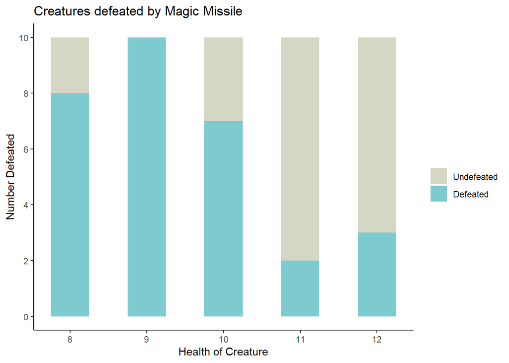

```r
ggplot(data = magic_missile, aes(x = Health, fill = as.factor(Defeated))) +
  geom_histogram(bins = 9) +
  scale_y_continuous(name="Number Defeated", breaks=seq(0,10,2)) +
  xlab("Health of Creature") +
  scale_fill_manual("", values = c("#D6D6C5", "#7DCBCE"), labels = c("Undefeated", "Defeated")) +
  labs(title = "Creatures defeated by Magic Missile") +
  theme_classic()
```

### Research Question

The question we will answer is at what point is a first level magic missile ineffective against single targets? It should be noted that the health of the target or the total of the roll could be used as the quantitative variable for the analysis. For our purposes, we will use health so that we can apply our results before the roll is cast rather than after.

## Analysis

### Hypotheses

The hypotheses we will be testing are:

$$H_0:\beta_1 = 0$$
$$H_a:\beta_1 \neq 0$$
$$\alpha = .05$$

These hypotheses say that if there is a correlation between $x_i$ and $Y_i$ (creature health and if they get defeated with magic missile).

### Logistic Regression

The probability of defeating a creature with magic missile based on its health is given by the following equation:

$$P(Y_i = 1|x_i)\approx\frac{e^{\beta_0 + \beta_{1}x_i}}{1 + e^{\beta_0 +
\beta_{1}x_i}} = \pi_i$$

##### where:

- $Y_i = 1$ means the creature was defeated
- $Y_i = 0$ means the creature was not defeated
- $x_i$ is the health of the creature being attacked

```r
mm.glm <- glm(Defeated ~ Health, data = magic_missile, family=binomial)
pander(summary(mm.glm))
```

|  | Estimate | Std. Error | z value | Pr(>\|z\|) |
| --- | --- | --- | --- | --- |
| **(Intercept)** | 9.756 | 2.894 | 3.371 | 0.0007485 |
| **Health** | -0.9192 | 0.2784 | -3.301 | 0.000962 |

(Dispersion parameter for binomial family taken to be 1 )

| Null deviance: | 67.30 on 49 degrees of freedom |
| --- | --- |
| Residual deviance: | 52.45 on 48 degrees of freedom |

```r
b <- mm.glm$coefficients
```

Plugging in the values of $\beta_0 = 9.756$ and $\beta_1 = -0.919$ gives us the complete logistical regression model:

$$P(Y_i = 1|x_i)\approx\frac{e^{9.756 -0.919x_i}}{1 + e^{9.756 -0.919x_i}}
= \pi_i$$

### Plot

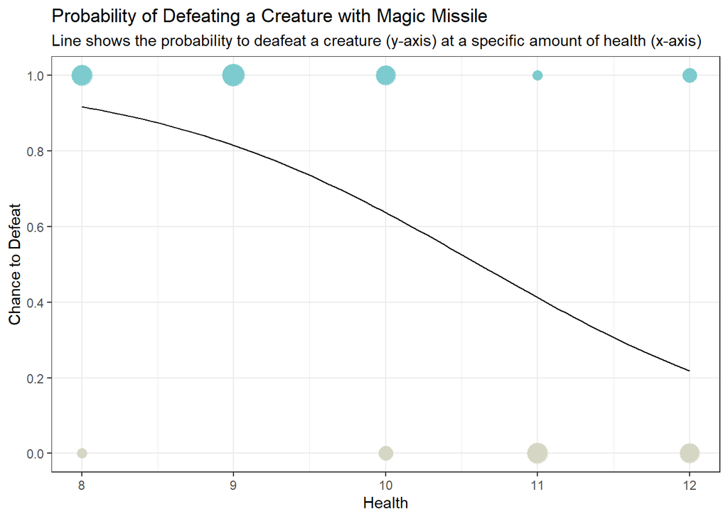

```r
ggplot(data=magic_missile, aes(x=Health,y=Defeated)) +
  geom_count(aes(color = factor(Defeated)), show.legend = FALSE) +
  labs(title = "Probability of Defeating a Creature with Magic Missile", subtitle = "Line shows the probability to deafeat a creature (y-axis) at a specific amount of health (x-axis)") +
  scale_y_continuous(name="Chance to Defeat", breaks=seq(0,1,.2)) +
  geom_smooth(method="glm", method.args = list(family="binomial"), se=FALSE, aes(color = "black"), linewidth = .5, show.legend = FALSE) +
  scale_color_manual(values = c("#D6D6C5", "#7DCBCE", "black")) +
  scale_size_continuous(range = c(3, 7)) +
  theme_bw() +
  theme(panel.grid.minor.y = element_blank())
```

### Goodness of Fit

```r
# Deviance Goodness-of-fit Test (duplicates in every x-value)
#deviance <- mm.glm$deviance
#deviance.df <- mm.glm$df.residual
#pchisq(deviance, deviance.df, lower.tail=FALSE)

# Hosmer-Lemeshow Goodness-of-Fit Test (few to no duplicate x values)
pander(hoslem.test(mm.glm$y, mm.glm$fitted, g=5))
```

Hosmer and Lemeshow goodness of fit (GOF) test: `mm.glm$y, mm.glm$fitted`

| Test statistic | df | P value |
| --- | --- | --- |
| 6.484 | 3 | 0.0903 |

With a p-value of .0903, we determine that the data is a good fit.

## Conclusion

In other words, we have proven that the health of an enemy does effect the chance of killing it with Magic Missile. This much seems obvious, but this analysis can also tell us the chance of defeating an enemy based on its health. These estimated probabilities are shown in the chart below.

| Health | Probability |
| --- | --- |
| 7 | 0.965 |
| 8 | 0.917 |
| 9 | 0.815 |
| 10 | 0.637 |
| 11 | 0.412 |
| 12 | 0.218 |
| 13 | 0.1 |
| 14 | 0.043 |
| 15 | 0.017 |